# Project Introduction

## Location-Related

```python
if _LITE_SWITCH_:
    pass
elif _SPARK_:
    pass
else:
    try:
        del data
        del reports, stats
    except:
        pass
```

```python
if _SPARK_:
    spark = SparkSession.builder.appName("Accident Data Project").getOrCreate()
    data = spark.read.csv('AccidentData_Clean.csv',header=True,inferSchema=True)
else:
    if _LITE_SWITCH_:
        data = pd.read_csv('AccidentData_Sampled_Clean.csv')
    else:
        tgt_cols = ['State','Region','SubRegion','AA_Region','BEA_Region','Federal','Bridge']
        data = pd.read_csv('AccidentData_Clean.csv',usecols = tgt_cols + ['Severity','Distance(mi)','Time_of_Impact(hr)'])
```

### By Different Region Classifications

```
Based on the ANOVA test's p-value of 0.000, we reject the null hypothesis that there is no significant difference in incident duration across different Regions.
Based on the ANOVA test's p-value of 0.000, we reject the null hypothesis that there is no significant difference in incident distance across different Regions.
Based on the CHI-Squared test's p-value of 0.000, we reject the null hypothesis that there is no significant difference in incident severity across different Regions.
```

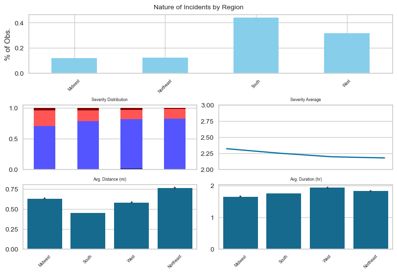

| Region | Severity | Time_of_Impact(hr) | Distance(mi) |
| --- | --- | --- | --- |
| Midwest | 2.321 | 1.652 | 0.631 |
| Northeast | 2.251 | 1.827 | 0.765 |
| South | 2.195 | 1.755 | 0.452 |
| West | 2.178 | 1.934 | 0.582 |

```python
reports,stats = test_results('Region',data);
data.groupby('Region')[['Severity','Time_of_Impact(hr)','Distance(mi)']].mean()
```

```
Based on the ANOVA test's p-value of 0.000, we reject the null hypothesis that there is no significant difference in incident duration across different SubRegions.
Based on the ANOVA test's p-value of 0.000, we reject the null hypothesis that there is no significant difference in incident distance across different SubRegions.
Based on the CHI-Squared test's p-value of 0.000, we reject the null hypothesis that there is no significant difference in incident severity across different SubRegions.
```

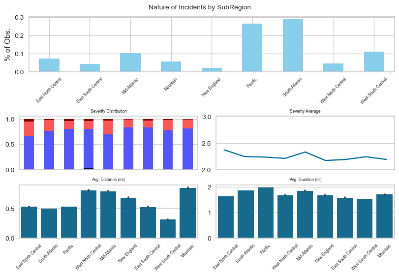

| SubRegion | Severity | Time_of_Impact(hr) | Distance(mi) |
| --- | --- | --- | --- |
| East North Central | 2.370 | 1.634 | 0.525 |
| East South Central | 2.245 | 1.585 | 0.519 |
| Mid-Atlantic | 2.235 | 1.858 | 0.784 |
| Mountain | 2.210 | 1.711 | 0.840 |
| New England | 2.330 | 1.679 | 0.674 |
| Pacific | 2.171 | 1.981 | 0.528 |
| South Atlantic | 2.190 | 1.869 | 0.497 |
| West North Central | 2.241 | 1.682 | 0.802 |
| West South Central | 2.191 | 1.519 | 0.311 |

```python
reports,stats = test_results('SubRegion',data);
data.groupby('SubRegion')[['Severity','Time_of_Impact(hr)','Distance(mi)']].mean()
```

```
Based on the ANOVA test's p-value of 0.000, we reject the null hypothesis that there is no significant difference in incident duration across different AA_Regions.
Based on the ANOVA test's p-value of 0.000, we reject the null hypothesis that there is no significant difference in incident distance across different AA_Regions.
Based on the CHI-Squared test's p-value of 0.000, we reject the null hypothesis that there is no significant difference in incident severity across different AA_Regions.
```

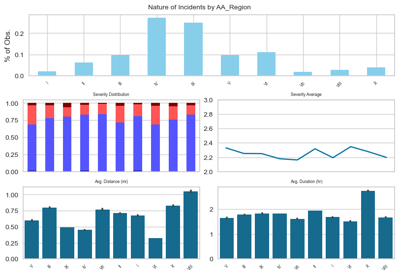

| AA_Region | Severity | Time_of_Impact(hr) | Distance(mi) |
| --- | --- | --- | --- |
| I | 2.330 | 1.679 | 0.674 |
| II | 2.252 | 1.946 | 0.711 |
| III | 2.250 | 1.782 | 0.796 |
| IV | 2.179 | 1.834 | 0.451 |
| IX | 2.162 | 1.837 | 0.490 |
| V | 2.317 | 1.659 | 0.598 |
| VI | 2.193 | 1.521 | 0.322 |
| VII | 2.347 | 1.614 | 0.767 |
| VIII | 2.276 | 1.672 | 1.052 |
| X | 2.198 | 2.749 | 0.828 |

```python
reports,stats = test_results('AA_Region',data)
data.groupby('AA_Region')[['Severity','Time_of_Impact(hr)','Distance(mi)']].mean()
```

```
Based on the ANOVA test's p-value of 0.000, we reject the null hypothesis that there is no significant difference in incident duration across different BEA_Regions.
Based on the ANOVA test's p-value of 0.000, we reject the null hypothesis that there is no significant difference in incident distance across different BEA_Regions.
Based on the CHI-Squared test's p-value of 0.000, we reject the null hypothesis that there is no significant difference in incident severity across different BEA_Regions.
```

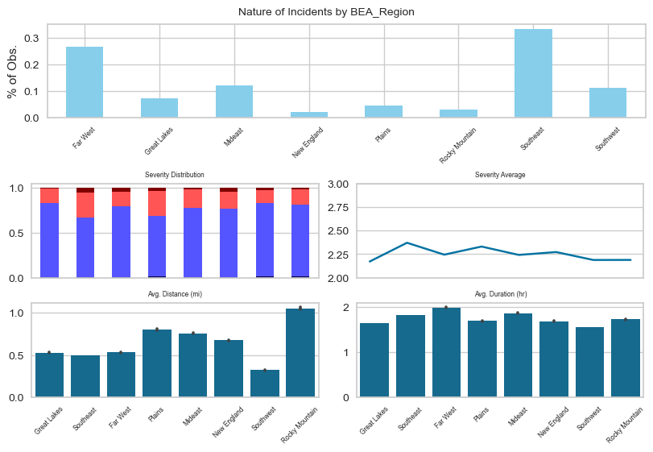

| BEA_Region | Severity | Time_of_Impact(hr) | Distance(mi) |
| --- | --- | --- | --- |
| Far West | 2.171 | 1.982 | 0.531 |
| Great Lakes | 2.370 | 1.634 | 0.525 |
| Mideast | 2.244 | 1.857 | 0.758 |
| New England | 2.330 | 1.679 | 0.674 |
| Plains | 2.241 | 1.682 | 0.802 |
| Rocky Mountain | 2.272 | 1.717 | 1.054 |
| Southeast | 2.188 | 1.813 | 0.495 |
| Southwest | 2.188 | 1.543 | 0.321 |

```python
reports,stats = test_results('BEA_Region',data)
data.groupby('BEA_Region')[['Severity','Time_of_Impact(hr)','Distance(mi)']].mean()
```

### By State

```python
states = data['State'].unique()

for state in states:
    print(state + ':')
    data['inState'] = data['State'] == state
    test_results('inState',data,visuals=False)
    print('-'*75)
```

```
OH:
Based on the ANOVA test's p-value of 0.000, we reject the null hypothesis that there is no significant difference in incident duration across different inStates.
Based on the ANOVA test's p-value of 0.424, we fail to reject the null hypothesis that there is no significant difference in incident distance across different inStates.
Based on the CHI-Squared test's p-value of 0.000, we reject the null hypothesis that there is no significant difference in incident severity across different inStates.
---------------------------------------------------------------------------
WV:
Based on the ANOVA test's p-value of 0.000, we reject the null hypothesis that there is no significant difference in incident duration across different inStates.
Based on the ANOVA test's p-value of 0.000, we reject the null hypothesis that there is no significant difference in incident distance across different inStates.
Based on the CHI-Squared test's p-value of 0.000, we reject the null hypothesis that there is no significant difference in incident severity across different inStates.
---------------------------------------------------------------------------
CA:
Based on the ANOVA test's p-value of 0.000, we reject the null hypothesis that there is no significant difference in incident duration across different inStates.
Based on the ANOVA test's p-value of 0.000, we reject the null hypothesis that there is no significant difference in incident distance across different inStates.
Based on the CHI-Squared test's p-value of 0.000, we reject the null hypothesis that there is no significant difference in incident severity across different inStates.
---------------------------------------------------------------------------
FL:
Based on the ANOVA test's p-value of 0.000, we reject the null hypothesis that there is no significant difference in incident duration across different inStates.
Based on the ANOVA test's p-value of 0.000, we reject the null hypothesis that there is no significant difference in incident distance across different inStates.
Based on the CHI-Squared test's p-value of 0.000, we reject the null hypothesis that there is no significant difference in incident severity across different inStates.
---------------------------------------------------------------------------
GA:
Based on the ANOVA test's p-value of 0.000, we reject the null hypothesis that there is no significant difference in incident duration across different inStates.
Based on the ANOVA test's p-value of 0.000, we reject the null hypothesis that there is no significant difference in incident distance across different inStates.
Based on the CHI-Squared test's p-value of 0.000, we reject the null hypothesis that there is no significant difference in incident severity across different inStates.
---------------------------------------------------------------------------
SC:
Based on the ANOVA test's p-value of 0.000, we reject the null hypothesis that there is no significant difference in incident duration across different inStates.
Based on the ANOVA test's p-value of 0.000, we reject the null hypothesis that there is no significant difference in incident distance across different inStates.
Based on the CHI-Squared test's p-value of 0.000, we reject the null hypothesis that there is no significant difference in incident severity across different inStates.
---------------------------------------------------------------------------
NE:
Based on the ANOVA test's p-value of 0.000, we reject the null hypothesis that there is no significant difference in incident duration across different inStates.
Based on the ANOVA test's p-value of 0.000, we reject the null hypothesis that there is no significant difference in incident distance across different inStates.
Based on the CHI-Squared test's p-value of 0.000, we reject the null hypothesis that there is no significant difference in incident severity across different inStates.
---------------------------------------------------------------------------
IA:
Based on the ANOVA test's p-value of 0.000, we reject the null hypothesis that there is no significant difference in incident duration across different inStates.
Based on the ANOVA test's p-value of 0.000, we reject the null hypothesis that there is no significant difference in incident distance across different inStates.
Based on the CHI-Squared test's p-value of 0.000, we reject the null hypothesis that there is no significant difference in incident severity across different inStates.
---------------------------------------------------------------------------
```

[output cut: 190 more lines]

```
ND:
Based on the ANOVA test's p-value of 0.051, we fail to reject the null hypothesis that there is no significant difference in incident duration across different inStates.
Based on the ANOVA test's p-value of 0.000, we reject the null hypothesis that there is no significant difference in incident distance across different inStates.
Based on the CHI-Squared test's p-value of 0.000, we reject the null hypothesis that there is no significant difference in incident severity across different inStates.
---------------------------------------------------------------------------
MT:
Based on the ANOVA test's p-value of 0.000, we reject the null hypothesis that there is no significant difference in incident duration across different inStates.
Based on the ANOVA test's p-value of 0.000, we reject the null hypothesis that there is no significant difference in incident distance across different inStates.
Based on the CHI-Squared test's p-value of 0.000, we reject the null hypothesis that there is no significant difference in incident severity across different inStates.
---------------------------------------------------------------------------
SD:
Based on the ANOVA test's p-value of 0.000, we reject the null hypothesis that there is no significant difference in incident duration across different inStates.
Based on the ANOVA test's p-value of 0.000, we reject the null hypothesis that there is no significant difference in incident distance across different inStates.
Based on the CHI-Squared test's p-value of 0.000, we reject the null hypothesis that there is no significant difference in incident severity across different inStates.
---------------------------------------------------------------------------
```

```python
data.groupby('State')[['Severity','Time_of_Impact(hr)','Distance(mi)']].mean()
```

| State | Severity | Time_of_Impact(hr) | Distance(mi) |
| --- | --- | --- | --- |
| AL | 2.243 | 1.418 | 0.474 |
| AR | 2.264 | 1.728 | 1.427 |
| AZ | 2.116 | 1.651 | 0.534 |
| CA | 2.166 | 1.851 | 0.481 |
| CO | 2.438 | 1.512 | 0.873 |
| CT | 2.346 | 2.154 | 1.125 |
| DC | 2.137 | 1.996 | 0.392 |
| DE | 2.254 | 1.548 | 0.444 |
| FL | 2.141 | 2.178 | 0.523 |
| GA | 2.507 | 1.598 | 0.617 |
| IA | 2.418 | 1.736 | 1.908 |
| ID | 2.123 | 2.704 | 1.384 |
| IL | 2.383 | 1.714 | 0.379 |
| IN | 2.395 | 1.746 | 1.035 |
| KS | 2.284 | 1.726 | 0.849 |
| KY | 2.454 | 1.424 | 0.435 |
| LA | 2.125 | 1.513 | 0.405 |
| MA | 2.293 | 1.093 | 0.247 |
| MD | 2.324 | 1.865 | 0.678 |
| ME | 2.204 | 2.442 | 0.903 |
| MI | 2.337 | 1.481 | 0.435 |
| MN | 2.163 | 1.731 | 0.810 |
| MO | 2.404 | 1.762 | 0.524 |
| MS | 2.342 | 1.719 | 0.715 |
| MT | 2.036 | 2.062 | 2.251 |
| NC | 2.130 | 1.797 | 0.290 |
| ND | 2.016 | 1.731 | 1.995 |
| NE | 2.177 | 1.053 | 0.326 |
| NH | 2.244 | 2.008 | 0.521 |
| NJ | 2.236 | 1.964 | 0.601 |
| NM | 2.374 | 1.687 | 1.219 |
| NV | 2.233 | 2.125 | 0.838 |
| NY | 2.258 | 1.939 | 0.754 |
| OH | 2.354 | 1.585 | 0.557 |
| OK | 2.076 | 1.092 | 0.074 |
| OR | 2.113 | 3.100 | 1.011 |
| PA | 2.206 | 1.712 | 0.905 |
| RI | 2.461 | 1.404 | 0.274 |
| SC | 2.112 | 1.393 | 0.299 |
| SD | 2.407 | 3.695 | 2.216 |
| TN | 2.197 | 1.702 | 0.545 |
| TX | 2.222 | 1.574 | 0.280 |
| UT | 2.190 | 1.690 | 0.726 |
| VA | 2.278 | 1.727 | 0.757 |
| VT | 2.426 | 2.145 | 1.682 |
| WA | 2.344 | 2.175 | 0.474 |
| WI | 2.472 | 1.913 | 0.585 |
| WV | 2.158 | 3.731 | 1.164 |
| WY | 2.354 | 2.081 | 3.893 |

### Federal Roads

```
Based on the ANOVA test's p-value of 0.000, we reject the null hypothesis that there is no significant difference in incident duration across different Federals.
Based on the ANOVA test's p-value of 0.000, we reject the null hypothesis that there is no significant difference in incident distance across different Federals.
Based on the CHI-Squared test's p-value of 0.000, we reject the null hypothesis that there is no significant difference in incident severity across different Federals.
```

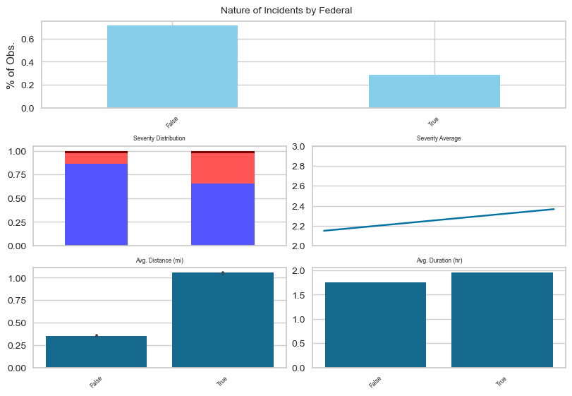

| Federal | Severity | Time_of_Impact(hr) | Distance(mi) |
| --- | --- | --- | --- |
| False | 2.150 | 1.751 | 0.354 |
| True | 2.367 | 1.955 | 1.056 |

```python
reports,stats = test_results('Federal',data)
data.groupby('Federal')[['Severity','Time_of_Impact(hr)','Distance(mi)']].mean()
```

```
Based on the ANOVA test's p-value of 0.000, we reject the null hypothesis that there is no significant difference in incident duration across different Bridges.
Based on the ANOVA test's p-value of 0.000, we reject the null hypothesis that there is no significant difference in incident distance across different Bridges.
Based on the CHI-Squared test's p-value of 0.000, we reject the null hypothesis that there is no significant difference in incident severity across different Bridges.
```

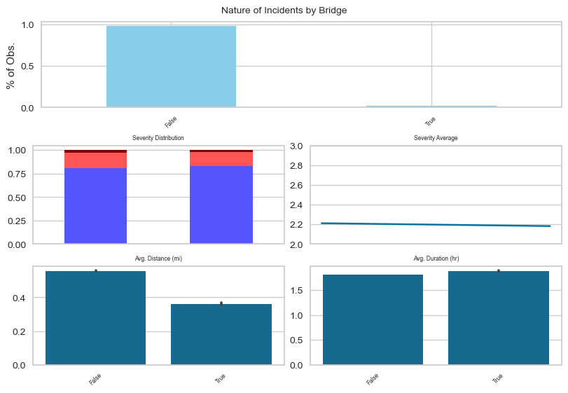

| Bridge | Severity | Time_of_Impact(hr) | Distance(mi) |
| --- | --- | --- | --- |
| False | 2.212 | 1.807 | 0.557 |
| True | 2.183 | 1.878 | 0.362 |

```python
reports,stats = test_results('Bridge',data)
data.groupby('Bridge')[['Severity','Time_of_Impact(hr)','Distance(mi)']].mean()
```

### Infrastructure

```python
infrastructures = ['Amenity','Bump','Crossing','Give_Way',
                   'Junction','No_Exit','Railway','Roundabout',
                   'Station','Stop','Traffic_Calming','Traffic_Signal',
                   'Turning_Loop'
                   ]
```

```python
if _SPARK_:
    spark = SparkSession.builder.appName("Accident Data Project").getOrCreate()
    data = spark.read.csv('AccidentData_Clean.csv',header=True,inferSchema=True)
else:
    if _LITE_SWITCH_:
        data = pd.read_csv('AccidentData_Sampled_Clean.csv')
    else:
        data = pd.read_csv('AccidentData_Clean.csv',usecols = infrastructures + ['Severity','Distance(mi)','Time_of_Impact(hr)'])
```

```python
for structure in infrastructures:
    if data[structure].sum() > 0:
        print(structure+": ")
        reports,stats = test_results(structure,data,visuals=False)
        display(data.groupby(structure)[['Severity','Time_of_Impact(hr)','Distance(mi)']].mean())
        print('-'*75)
    else:
        pass
```

```
Amenity:
Based on the ANOVA test's p-value of 0.000, we reject the null hypothesis that there is no significant difference in incident duration across different Amenitys.
Based on the ANOVA test's p-value of 0.000, we reject the null hypothesis that there is no significant difference in incident distance across different Amenitys.
Based on the CHI-Squared test's p-value of 0.000, we reject the null hypothesis that there is no significant difference in incident severity across different Amenitys.
```

| Amenity | Severity | Time_of_Impact(hr) | Distance(mi) |
| --- | --- | --- | --- |
| False | 2.213 | 1.810 | 0.559 |
| True | 2.069 | 1.719 | 0.128 |

```
---------------------------------------------------------------------------
Bump:
Based on the ANOVA test's p-value of 0.924, we fail to reject the null hypothesis that there is no significant difference in incident duration across different Bumps.
Based on the ANOVA test's p-value of 0.000, we reject the null hypothesis that there is no significant difference in incident distance across different Bumps.
Based on the CHI-Squared test's p-value of 0.000, we reject the null hypothesis that there is no significant difference in incident severity across different Bumps.
```

| Bump | Severity | Time_of_Impact(hr) | Distance(mi) |
| --- | --- | --- | --- |
| False | 2.211 | 1.809 | 0.553 |
| True | 2.095 | 1.805 | 0.233 |

```
---------------------------------------------------------------------------
Crossing:
Based on the ANOVA test's p-value of 0.000, we reject the null hypothesis that there is no significant difference in incident duration across different Crossings.
Based on the ANOVA test's p-value of 0.000, we reject the null hypothesis that there is no significant difference in incident distance across different Crossings.
Based on the CHI-Squared test's p-value of 0.000, we reject the null hypothesis that there is no significant difference in incident severity across different Crossings.
```

| Crossing | Severity | Time_of_Impact(hr) | Distance(mi) |
| --- | --- | --- | --- |
| False | 2.231 | 1.831 | 0.610 |
| True | 2.064 | 1.635 | 0.113 |

```
---------------------------------------------------------------------------
Give_Way:
Based on the ANOVA test's p-value of 0.000, we reject the null hypothesis that there is no significant difference in incident duration across different Give_Ways.
Based on the ANOVA test's p-value of 0.000, we reject the null hypothesis that there is no significant difference in incident distance across different Give_Ways.
Based on the CHI-Squared test's p-value of 0.000, we reject the null hypothesis that there is no significant difference in incident severity across different Give_Ways.
```

| Give_Way | Severity | Time_of_Impact(hr) | Distance(mi) |
| --- | --- | --- | --- |
| False | 2.212 | 1.810 | 0.554 |
| True | 2.173 | 1.546 | 0.305 |

```
---------------------------------------------------------------------------
Junction:
Based on the ANOVA test's p-value of 0.000, we reject the null hypothesis that there is no significant difference in incident duration across different Junctions.
Based on the ANOVA test's p-value of 0.000, we reject the null hypothesis that there is no significant difference in incident distance across different Junctions.
Based on the CHI-Squared test's p-value of 0.000, we reject the null hypothesis that there is no significant difference in incident severity across different Junctions.
```

| Junction | Severity | Time_of_Impact(hr) | Distance(mi) |
| --- | --- | --- | --- |
| False | 2.204 | 1.781 | 0.538 |
| True | 2.299 | 2.155 | 0.748 |

```
---------------------------------------------------------------------------
No_Exit:
Based on the ANOVA test's p-value of 0.002, we reject the null hypothesis that there is no significant difference in incident duration across different No_Exits.
Based on the ANOVA test's p-value of 0.000, we reject the null hypothesis that there is no significant difference in incident distance across different No_Exits.
Based on the CHI-Squared test's p-value of 0.000, we reject the null hypothesis that there is no significant difference in incident severity across different No_Exits.
```

| No_Exit | Severity | Time_of_Impact(hr) | Distance(mi) |
| --- | --- | --- | --- |
| False | 2.212 | 1.808 | 0.554 |
| True | 2.112 | 1.855 | 0.220 |

```
---------------------------------------------------------------------------
Railway:
Based on the ANOVA test's p-value of 0.000, we reject the null hypothesis that there is no significant difference in incident duration across different Railways.
Based on the ANOVA test's p-value of 0.000, we reject the null hypothesis that there is no significant difference in incident distance across different Railways.
Based on the CHI-Squared test's p-value of 0.000, we reject the null hypothesis that there is no significant difference in incident severity across different Railways.
```

| Railway | Severity | Time_of_Impact(hr) | Distance(mi) |
| --- | --- | --- | --- |
| False | 2.212 | 1.810 | 0.556 |
| True | 2.152 | 1.701 | 0.227 |

```
---------------------------------------------------------------------------
Roundabout:
Based on the ANOVA test's p-value of 0.122, we fail to reject the null hypothesis that there is no significant difference in incident duration across different Roundabouts.
Based on the ANOVA test's p-value of 0.000, we reject the null hypothesis that there is no significant difference in incident distance across different Roundabouts.
Based on the CHI-Squared test's p-value of 0.000, we reject the null hypothesis that there is no significant difference in incident severity across different Roundabouts.
```

| Roundabout | Severity | Time_of_Impact(hr) | Distance(mi) |
| --- | --- | --- | --- |
| False | 2.211 | 1.809 | 0.553 |
| True | 2.070 | 1.601 | 0.114 |

```
---------------------------------------------------------------------------
Station:
Based on the ANOVA test's p-value of 0.000, we reject the null hypothesis that there is no significant difference in incident duration across different Stations.
Based on the ANOVA test's p-value of 0.000, we reject the null hypothesis that there is no significant difference in incident distance across different Stations.
Based on the CHI-Squared test's p-value of 0.000, we reject the null hypothesis that there is no significant difference in incident severity across different Stations.
```

| Station | Severity | Time_of_Impact(hr) | Distance(mi) |
| --- | --- | --- | --- |
| False | 2.215 | 1.805 | 0.565 |
| True | 2.074 | 1.950 | 0.131 |

```
---------------------------------------------------------------------------
Stop:
Based on the ANOVA test's p-value of 0.000, we reject the null hypothesis that there is no significant difference in incident duration across different Stops.
Based on the ANOVA test's p-value of 0.000, we reject the null hypothesis that there is no significant difference in incident distance across different Stops.
Based on the CHI-Squared test's p-value of 0.000, we reject the null hypothesis that there is no significant difference in incident severity across different Stops.
```

| Stop | Severity | Time_of_Impact(hr) | Distance(mi) |
| --- | --- | --- | --- |
| False | 2.215 | 1.813 | 0.563 |
| True | 2.075 | 1.641 | 0.221 |

```
---------------------------------------------------------------------------
Traffic_Calming:
Based on the ANOVA test's p-value of 0.314, we fail to reject the null hypothesis that there is no significant difference in incident duration across different Traffic_Calmings.
Based on the ANOVA test's p-value of 0.000, we reject the null hypothesis that there is no significant difference in incident distance across different Traffic_Calmings.
Based on the CHI-Squared test's p-value of 0.000, we reject the null hypothesis that there is no significant difference in incident severity across different Traffic_Calmings.
```

| Traffic_Calming | Severity | Time_of_Impact(hr) | Distance(mi) |
| --- | --- | --- | --- |
| False | 2.211 | 1.809 | 0.554 |
| True | 2.126 | 1.833 | 0.205 |

```
---------------------------------------------------------------------------
Traffic_Signal:
Based on the ANOVA test's p-value of 0.000, we reject the null hypothesis that there is no significant difference in incident duration across different Traffic_Signals.
Based on the ANOVA test's p-value of 0.000, we reject the null hypothesis that there is no significant difference in incident distance across different Traffic_Signals.
Based on the CHI-Squared test's p-value of 0.000, we reject the null hypothesis that there is no significant difference in incident severity across different Traffic_Signals.
```

| Traffic_Signal | Severity | Time_of_Impact(hr) | Distance(mi) |
| --- | --- | --- | --- |
| False | 2.233 | 1.883 | 0.632 |
| True | 2.088 | 1.386 | 0.103 |

# 7-Advanced Analysis

## Possible

### Statistical Analyses with Subsets of Data

State-by-State

County-by-County

Year-by-Year

### Other

Interstate

Frequent Coordinates

```python
coords_count = data.value_counts(['Start_Lat','Start_Lng'])
coords_count = coords_count[coords_count > 30].reset_index()
```

[output not shown]

```python
lat,lng = coords_count.loc[0][['Start_Lat','Start_Lng']]
same_spot = data[(data['Start_Lat']==lat) & (data['Start_Lng']==lng)]
```

```python
same_spot.Weather_Condition.value_counts()
```

```python
same_spot[infrastructures].sum()
```

```python
same_spot['Severity'].value_counts()
```

```python
same_spot[['Year','Month']].value_counts().sort_index()
```

```python
same_spot[['DayofWeek','Hour']].value_counts().sort_index()
```

Commute Data (By State/County)

DBScan on Clustering

Interstate

Infrastructure Cooccurence

## Wish List

### Unusual Weather

Does driving in unexpected weather--based on area, time of year and/or both--create a higher likelihood of an accident.

### Highway's Near Urban Areas

For cross-state

### Naturual Language

Examination of the description feature.

### Safety Infrastructure

Does certain road infrastructure projects help reduce the number of incidents?

### New Traffic Pattern

Does the existence of a new traffic pattern in the area increase the likelihood of an accident?

### Recent Accident Indicator

Does the presence of one accident, predict another.

# 7-Insights & Conclusions

## Basic Insights

### Annual Distinctions

Number of Accidents; Distribution of Severities; Length of Impact

```python
data['State'].value_counts()
```

### Temporal & Spatial Considerations

How do accident counts relate to different times of the day and for different region types (urban vs rural)?

### Weather Considerations

Does certain weather conditions produce more severe incidents?

# Advanced (Wish List) Analysis

## Unusual Weather

Does driving in unexpected weather--based on area, time of year and/or both--create a higher likelihood of an accident.

## Highway's Near Urban Areas

For cross-state

## Naturual Language

Examination of the description feature.

## Safety Infrastructure

Does certain road infrastructure projects help reduce the number of incidents?

## New Traffic Pattern

Does the existence of a new traffic pattern in the area increase the likelihood of an accident?

## Recent Accident Indicator

Does the presence of one accident, predict another.